# PEC2_Visualizacion_CARLOS_TORO

Carlos Toro

2024-04-22

# 1 Visualización de Datos. PEC1

# 2 Archivo de datos: Emisiones de CO2 por país.

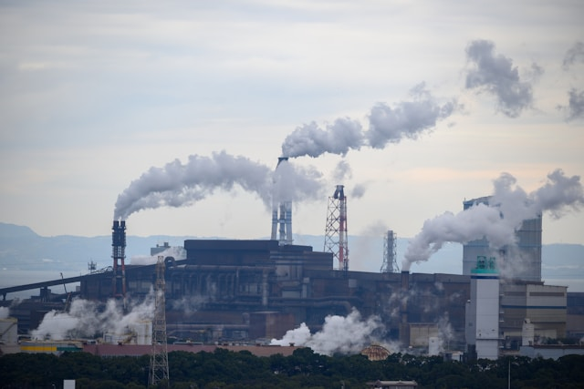

El presente estudio esta basado en el dataset descargado de:

https://www.kaggle.com/datasets/thedevastator/global-fossil-co2-emissions-by-country-2002-2022

**Descripción**:

Se trata de un estudio de las emisiones de CO2 por país desde 1750.

La siguiente tabla describe cada uno de las columnas.

| **Column name** | **Description** |
| --- | --- |
| **Country** | The name of the country. (String) |
| **ISO 3166-1 alpha-3** | The three-letter code for the country. (String) |
| **Year** | The year of the data. (Integer) |
| **Total** | The total amount of CO2 emissions for the country in the given year. (Float) |
| **Coal** | The amount of CO2 emissions from coal for the country in the given year. (Float) |
| **Oil** | The amount of CO2 emissions from oil for the country in the given year. (Float) |
| **Gas** | The amount of CO2 emissions from gas for the country in the given year. (Float) |
| **Cement** | The amount of CO2 emissions from cement production for the country in the given year. (Float) |
| **Flaring** | The amount of CO2 emissions from flaring operations for the country in the given year. (Float) |
| **Other** | The amount of CO2 emissions from other sources for the country in the given year. (Float) |
| **Per Capita** | The amount of CO2 emissions per capita for the country in the given year. (Float) |

**Licencia:**

**License: [CC0 1.0 Universal (CC0 1.0) - Public Domain Dedication](https://creativecommons.org/publicdomain/zero/1.0/)**  
No Copyright - You can copy, modify, distribute and perform the work, even for commercial purposes, all without asking permission. [See Other Information](https://creativecommons.org/publicdomain/zero/1.0/).

# 3 Visualizaciones

## 3.1 Visualización 1: Histograma.

Se trata de una gráfica comparativa entre las emisiones por década de los paises Rusia, China y USA desde 1910.

**Técnica usada**: R con R-Notebook.

Pulse para acceder al histograma

Rescargar el arhivo R

## 3.2 Visualización 2: Proportional Symbol Map.

Se trata de un mapa comparativo de las emisiones totales a lo largo de la historia de cada país.

**Técnica usada**: Tableau.

Proportional Symbol map

Descargar el mapa como PDF

Descargar el archivo twb de Tableau

## 3.3 Visualización 3: Ridgeline Charts.

Se trata de una gráfica interactiva de cada país con frecuencias de las emisiones por componentes desde 1910.

Es muy importante entender que para leer correctamente esta gráfica, los valores que tienen importancia son los que están desplazados a la derecha, cuantos más valores veamos a la derecha mayor es la emisión del pais de ese componente:

**Técnica usada**: HTML con javascript y librería D3.

Pulse para acceder al Ridgeline chart

# 4 Descargar la práctica.

Se puede descargar todo el contenido de esta práctica mendiante este link.